# A Causal Impact Exaple

## Readind data

The data set has four columns:

- **days_tweet**: Each value represents the day of the time period analyzed.
- **categ**: Each of the categories obtained at LIWC.
- **values_baseline**: Average values obtained for each day and each category. These values are for users who have not interacted with the online campaign.
- **values_neda**: Average values obtained for each day and each category. These values are for users who have interacted with the online campaign.

```r
library(tidyverse)
df <- read_csv(here::here("data", "data_causal_impact.csv"))

df
```

```
## # A tibble: 2,263 × 4
##    days_tweet categ   values_baseline values_neda
##         <dbl> <chr>             <dbl>       <dbl>
##  1        -15 fun               7.08       5.57
##  2        -15 pronoun           2.12       1.73
##  3        -15 ppron             1.35       1.16
##  4        -15 i                 0.615      0.495
##  5        -15 we                0.131      0.128
##  6        -15 you               0.335      0.345
##  7        -15 shehe             0.163      0.0964
##  8        -15 they              0.111      0.0908
##  9        -15 ipron             0.766      0.570
## 10        -15 article           0.902      0.634
## # … with 2,253 more rows
```

For this example we select the “risk” category. We plot values from the baseline and NEDA users:

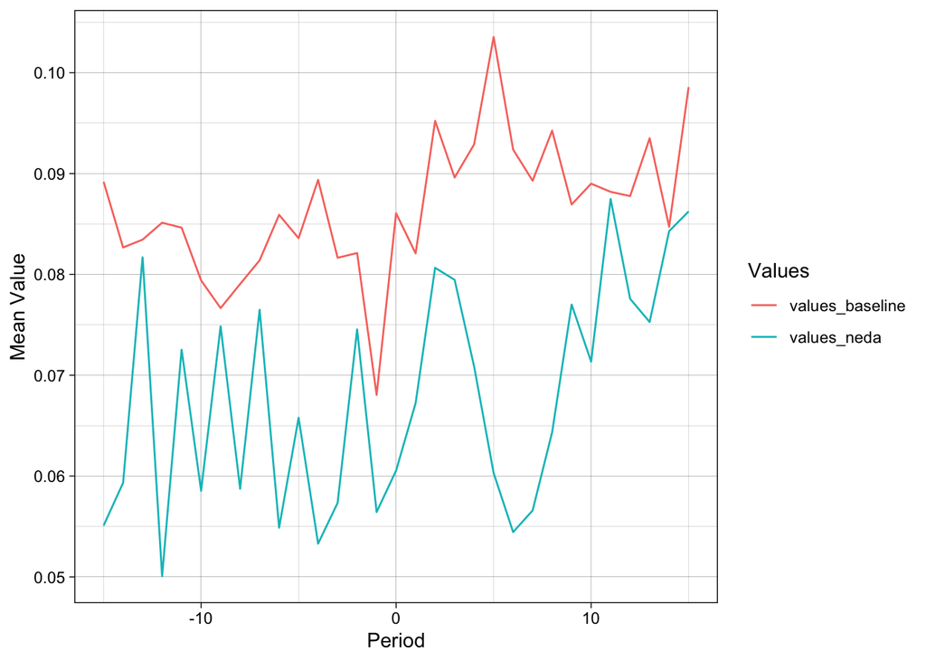

```r
df %>%
  filter(categ == "risk") -> df_risk

df_risk %>%
  pivot_longer(cols = values_baseline:values_neda) %>%
  ggplot(aes(x = days_tweet, y = value, color = name)) +
  geom_line() +
  xlab("Period") +
  ylab("Mean Value") +
  labs(color = "Values") +
  theme_linedraw()
```

## Causal Impact Function

- `pre_period`: A vector specifying the first and the last time point of the pre-intervention period in the response vector y. This period can be thought of as a training period, used to determine the relationship between the response variable and the covariates.
- `post_period`A vector specifying the first and the last day of the post-intervention period we wish to study. This is the period after the intervention has begun whose effect we are interested in.

```r
pre_period <- c(1, 16)
post_period <- c(17, 31)

df_risk %>%
  select(values_baseline, values_neda) -> df_risk

impact <- CausalImpact::CausalImpact(df_risk, pre.period = pre_period, post.period = post_period)
```

To obtain a numerical summary of the analysis, we use:

```r
summary(impact)
```

```
## Posterior inference {CausalImpact}
##
##                          Average           Cumulative
## Actual                   0.091             1.368
## Prediction (s.d.)        0.082 (0.0014)    1.225 (0.0212)
## 95% CI                   [0.079, 0.084]    [1.182, 1.266]
##
## Absolute effect (s.d.)   0.0095 (0.0014)   0.1432 (0.0212)
## 95% CI                   [0.0068, 0.012]   [0.1024, 0.186]
##
## Relative effect (s.d.)   12% (1.7%)        12% (1.7%)
## 95% CI                   [8.4%, 15%]       [8.4%, 15%]
##
## Posterior tail-area probability p:   0.001
## Posterior prob. of a causal effect:  99.9%
##
## For more details, type: summary(impact, "report")
```

## Ploting

By default, the plot contains three panels. The first panel shows the data and a counterfactual prediction for the post-treatment period. The second panel shows the difference between observed data and counterfactual predictions. This is the pointwise causal effect, as estimated by the model. The third panel adds up the pointwise contributions from the second panel, resulting in a plot of the cumulative effect of the intervention.

Remember, once again, that all of the above inferences depend critically on the assumption that the covariates were not themselves affected by the intervention. The model also assumes that the relationship between covariates and treated time series, as established during the pre-period, remains stable throughout the post-period.

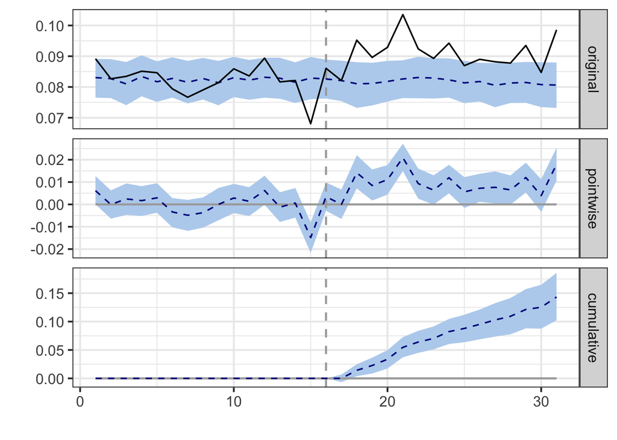

```r
plot(impact)
```

## Report

For additional guidance about the correct interpretation of the summary table, the package provides a verbal interpretation, which we can print using:

```r
summary(impact, "report")
```

[output not shown]

You can find more examples in the GitHub repository. The explanations of the models come from the texts used in this example: https://google.github.io/CausalImpact/CausalImpact.html

## References

- Brodersen et al., 2015, Annals of Applied Statistics. Inferring causal impact using Bayesian structural time-series models. https://research.google/pubs/pub41854/